# GOV321

## Visualizing Data

When visualizing data, it is important to choose the right type of visualization based on the type of variables you are working with:

- **Categorical Variables**: Use bar plots to display counts or proportions of categories.
- **Numeric Variables**: Use histograms or box plots to show distributions.
- **Relationships Between Variables**: Use scatter plots or grouped box plots depending on the type of data.

Below, we walk through basic visualizations for categorical and numeric variables, as well as methods for exploring relationships between them.

#### 1. Bar Plots for Categorical Variables

A bar plot is an excellent way to visualize the counts (or proportions) of categories in a variable. For example, to visualize **vote intentions**, we can create a bar plot using the `barplot()` function and the output of `table()`:

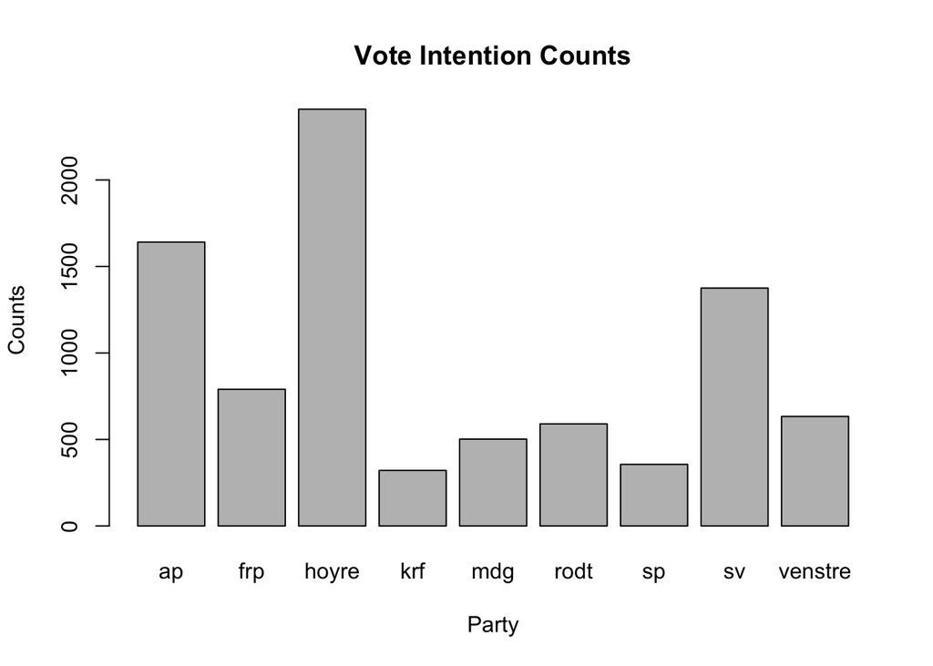

```r
# Bar plot for vote intentions
barplot(table(ncp_min$vote_intention),
        ylab = "Counts", xlab = "Party", main = "Vote Intention Counts")
```

If you want to break this down by another variable, such as **gender**, you can create a grouped bar plot:

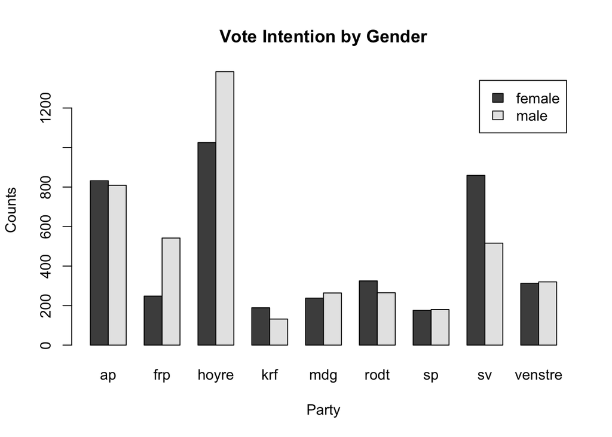

```r
# Bar plot for vote intention by gender
barplot(table(ncp_min$gender, ncp_min$vote_intention),
        beside = TRUE, legend.text = TRUE,
        ylab = "Counts", xlab = "Party", main = "Vote Intention by Gender")
```

#### 2. Histograms for Numeric Variables

To visualize the distribution of numeric variables, use a histogram. A histogram automatically bins numeric values into intervals and shows the frequency of observations within each bin. For example, let’s examine the distribution of the **left-right scale** variable:

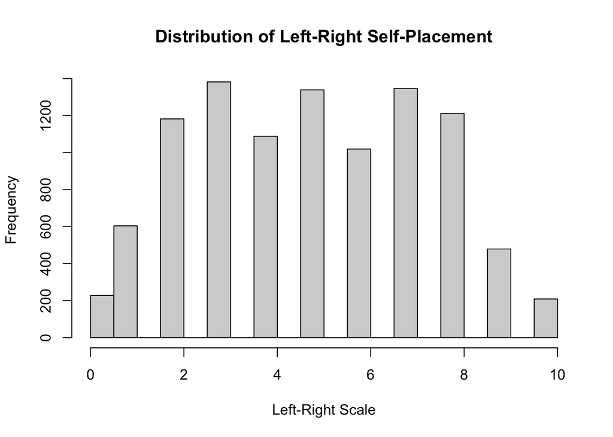

```r
# Histogram for left-right self-placement
hist(ncp_min$lr_scale,
     main = "Distribution of Left-Right Self-Placement",
     xlab = "Left-Right Scale")
```

#### 3. Box Plots for Numeric Variables

A box plot is useful for summarizing the distribution of a numeric variable by showing its median, quartiles, and potential outliers. For instance:

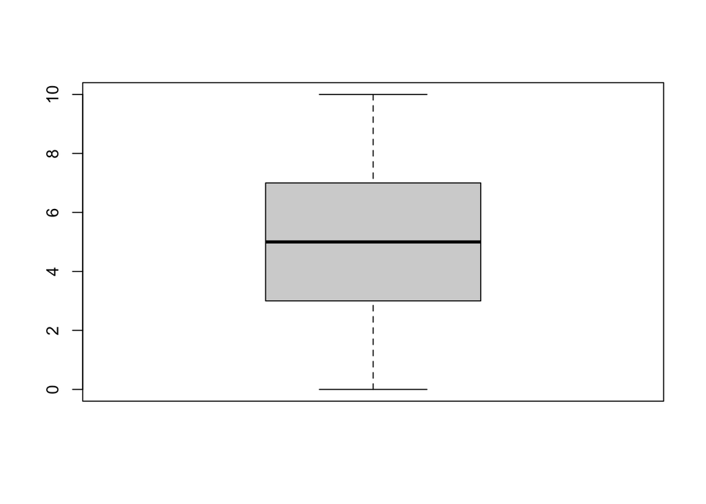

```r
# Box plot for left-right self-placement
boxplot(ncp_min$lr_scale)
```

You can also use a box plot to compare the distribution of a numeric variable across categories of a categorical variable. For example, to explore **left-right self-placement** by **voting intention**:

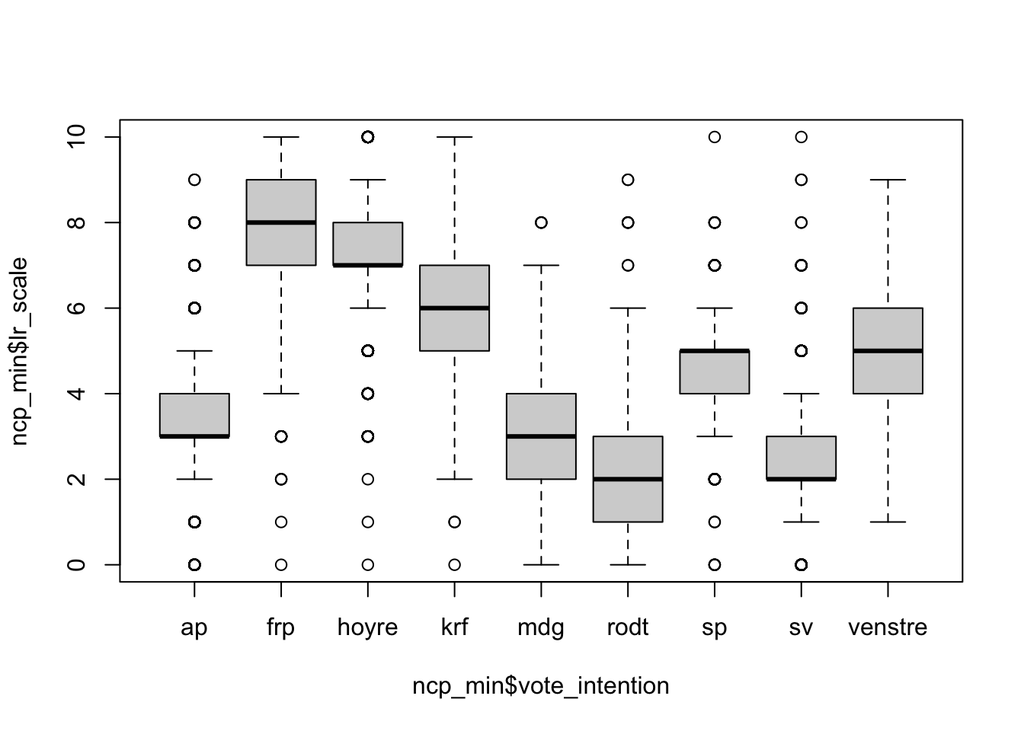

```r
boxplot(ncp_min$lr_scale~ncp_min$vote_intention)
```

> Question: Which party has the most left-wing and right-wing voters, respectively?

#### 4. Scatter Plots for Relationships Between Numeric Variables

A scatter plot is used to examine the relationship between two numeric variables. It uses dots to represent individual data points. For example, let’s look at the relationship between **left-right ideology** (`lr_scale`) and **immigration attitudes** (`immigration`):

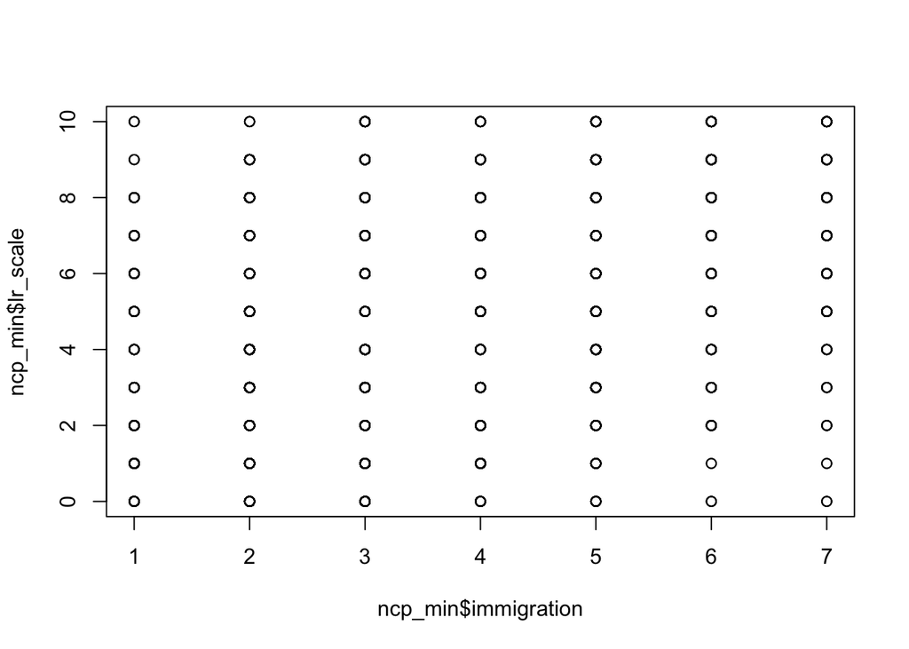

```r
# Basic scatter plot
plot(ncp_min$immigration, ncp_min$lr_scale)
```

Evidently, this scatter plot is not very informative. That is because both of our variables are **ordinal** (as opposed to continuous) and contain only a few distinct values. As a result, all the dots end up stacked on top of each other, making it difficult to discern any patterns.

To address this, we can use the `jitter()` function. This function adds a small amount of random noise (or “jitter”) to each data point, which helps to spread the points out and make the relationships more visible. By applying `jitter()` to both the **x-axis** and **y-axis** variables, we can get a better sense of the relationship between the two.

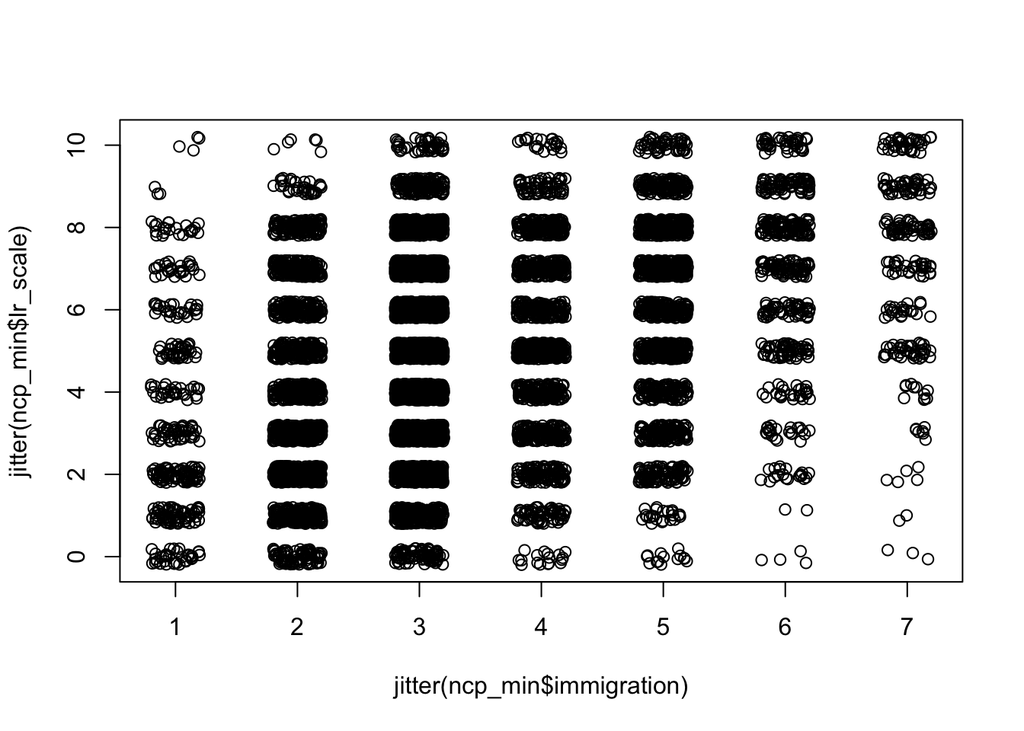

```r
# Scatter plot with jitter
plot(jitter(ncp_min$immigration), jitter(ncp_min$lr_scale))
```

> **Question:** What seems to be the relationship between left-right self-placement and attitudes towards immigration?

### Correlation

While the plots we have been through provides us with useful ways to visually represent the relationship between two variables, sometimes it is helpful to summarize the relationship with a number. For that purpose, we use the correlation coefficient.

Correlation measures the strength and direction of the relationship between two numeric variables. In R, we typically calculate the Pearson correlation coefficient, which quantifies how strongly two variables are linearly related. This coefficient ranges from:

- **-1**: Perfect negative correlation (as one variable increases, the other decreases).
- **0**: No linear correlation.
- **+1**: Perfect positive correlation (as one variable increases, the other also increases).

To calculate the correlation between two numeric variables, use the `cor()` function. For example, let’s examine the relationship between **left-right self-placement (`lr_scale`)** and **immigration attitudes (`immigration`)**:

```r
# Correlation between left-right self-placement and immigration attitudes
cor(ncp_min$lr_scale, ncp_min$immigration, use = "complete.obs")
```

```
## [1] 0.3492181
```

> **Question:** What is the correlation between left-right self-placement and immigration attitudes?